# Statistical Analysis of the N170

Ling

1/7/2018

## Executive Summary

Dataset is from this term’s EEG course, 11 participants’ N170 data included. Data was recorged from classic face recognition experiment, which has 2 variables and 4 conditions: `face gender (female vs. male)` and `face orientation (upright vs. inverted)`.

Identify the peak as the most negative point at both sides, and measure the *latency* of this peak. The *amplitude* was measured as the average voltage within the 120-220 time window.

Brain region was used as a constrain to measure the N170 over the areas where it is expected to occur:  
* Left: 58 + 59 + 65 + 69  
* Right: 89 + 90 + 91 + 96

So, firstly, an average across these channels to make sure that individual variability is taken into account.

Secondly and mainly, an ANOVA would be run separately on the *latency* and the *amplitude* of the N170 using: * hemisphere (left, right),  
* gender (male, female), and  
* face orientation (upright, inverted)  
as within-subject factors.

## Descritives Statistics

Extracting contidition means for amplitude and latency, respectively.

Table 1: Descriptive Statistics for N170 Amplitude

| gender_faceOri_hemi | N | Mean_amplitude | SD | Min | Max | SEM | % Missing |
| --- | --- | --- | --- | --- | --- | --- | --- |
| female_inv_L | 11 | 0.14 | 1.71 | -2.66 | 2.79 | 0.51 | 0 |
| female_inv_R | 11 | -0.24 | 2.95 | -5.84 | 5.00 | 0.89 | 0 |
| female_up_L | 11 | 1.99 | 2.74 | -0.55 | 8.22 | 0.83 | 0 |
| female_up_R | 11 | 1.91 | 2.80 | -3.36 | 5.15 | 0.84 | 0 |
| male_inv_L | 11 | 0.24 | 2.09 | -3.07 | 4.10 | 0.63 | 0 |
| male_inv_R | 11 | -0.06 | 3.08 | -5.65 | 5.07 | 0.93 | 0 |
| male_up_L | 11 | 1.99 | 2.90 | -0.63 | 8.16 | 0.87 | 0 |
| male_up_R | 11 | 1.86 | 2.57 | -3.43 | 5.41 | 0.77 | 0 |

Table 2: Descriptive Statistics for N170 Latency

| gender_faceOri_hemi | N | Mean_latency | SD | Min | Max | SEM | % Missing |
| --- | --- | --- | --- | --- | --- | --- | --- |
| female_inv_L | 11 | 179.18 | 16.21 | 153.5 | 218.5 | 4.89 | 0 |
| female_inv_R | 11 | 181.82 | 24.17 | 156.0 | 247.0 | 7.29 | 0 |
| female_up_L | 11 | 204.68 | 89.89 | 148.0 | 442.0 | 27.10 | 0 |
| female_up_R | 11 | 174.27 | 26.27 | 150.0 | 248.0 | 7.92 | 0 |
| male_inv_L | 11 | 190.41 | 47.08 | 150.5 | 328.5 | 14.19 | 0 |
| male_inv_R | 11 | 176.86 | 10.13 | 156.0 | 189.5 | 3.06 | 0 |
| male_up_L | 11 | 187.41 | 48.18 | 147.0 | 314.5 | 14.53 | 0 |
| male_up_R | 11 | 168.32 | 11.40 | 149.5 | 180.5 | 3.44 | 0 |

## EDA Plots

### Amplitude and latency interaction plot

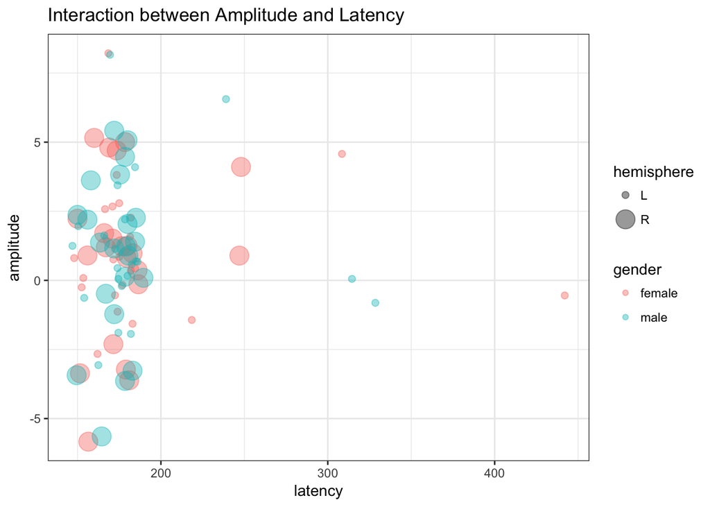

### Amplitude plot

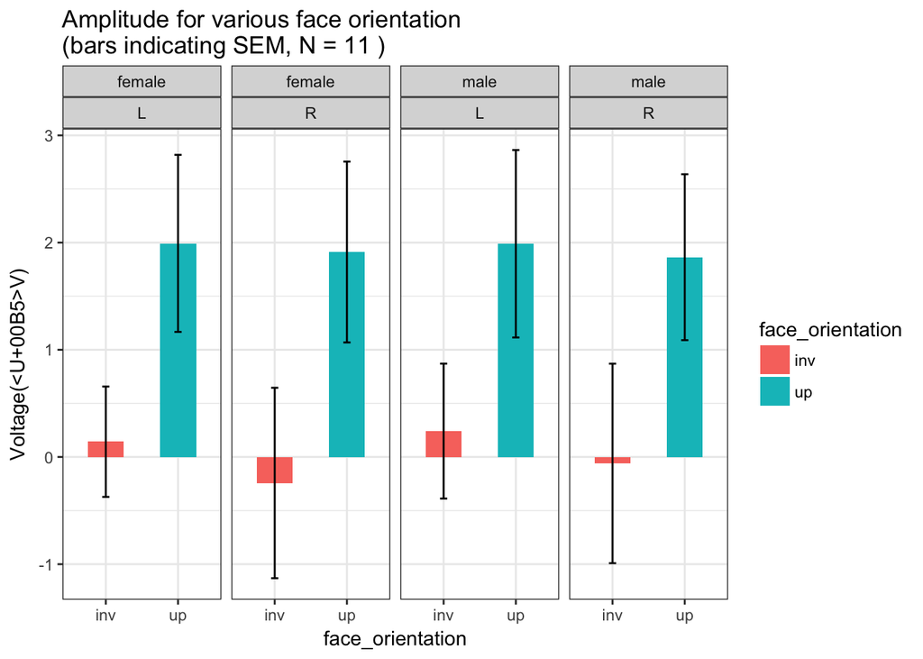

### Latency plot

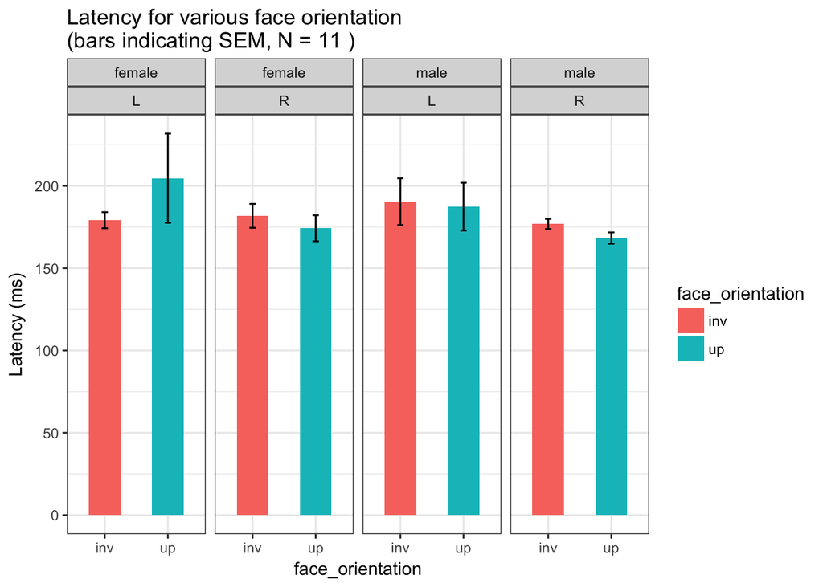

## Inferential Analysis

### ANOVA on Amplitude

1. **Two-way interactions plots**  
   A visual way to see hether different combinations of the levels of the factors differently affect the average amplitude.

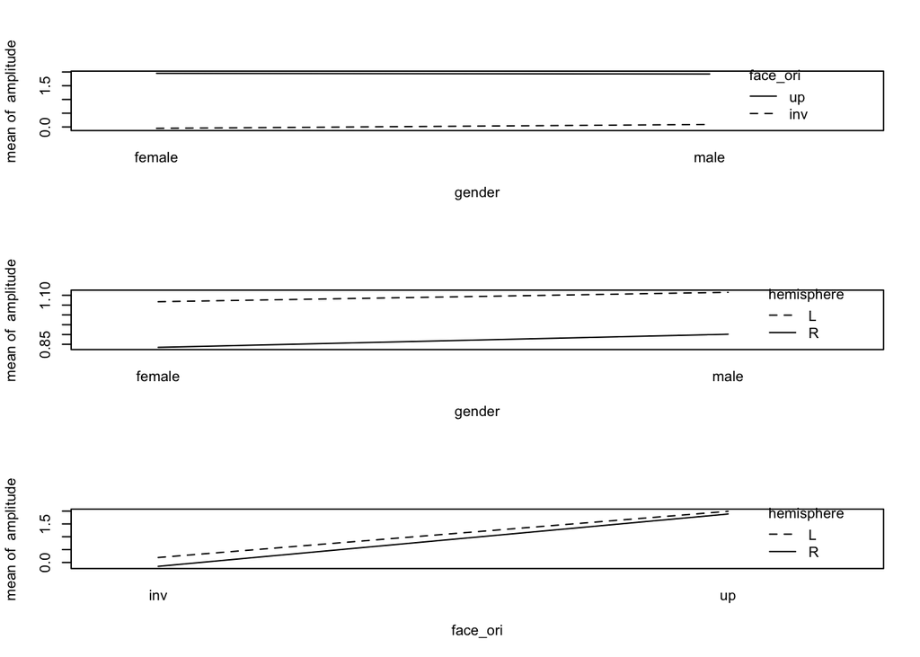

There may be an interaction between `face orientaion` and `hemisphere`, meaning that `face orientaion` might affect the `amplitude` differently based on whether it is combined with left or right hemisphere.

2. **Fit a Model**  
   Build a full model to see whether the differences between means plotted are significant or not.

```
##
##  Shapiro-Wilk normality test
##
## data:  N170_total$amplitude
## W = 0.98065, p-value = 0.2125
```

Table 3: ANOVA on N170 Amplitude

|  | Df | Sum Sq | Mean Sq | F value | Pr(>F) |
| --- | --- | --- | --- | --- | --- |
| gender | 1 | 0.07 | 0.07 | 0.01 | 0.92 |
| face_ori | 1 | 80.99 | 80.99 | 11.62 | 0.00 |
| hemisphere | 1 | 1.09 | 1.09 | 0.16 | 0.69 |
| gender:face_ori | 1 | 0.15 | 0.15 | 0.02 | 0.88 |
| gender:hemisphere | 1 | 0.00 | 0.00 | 0.00 | 0.99 |
| face_ori:hemisphere | 1 | 0.32 | 0.32 | 0.05 | 0.83 |
| gender:face_ori:hemisphere | 1 | 0.02 | 0.02 | 0.00 | 0.95 |
| Residuals | 80 | 557.77 | 6.97 | NA | NA |

Normality test showed amplitude data is normally distributed (p>.05), hence, a classical ANOVA was performed. Results showed that only main effect of `face orientation` is significant, F(1, 80) = 11.62, p < .001.

3. **Residuals Diagnostic plots**

```
## hat values (leverages) are all = 0.09090909
##  and there are no factor predictors; no plot no. 5
```

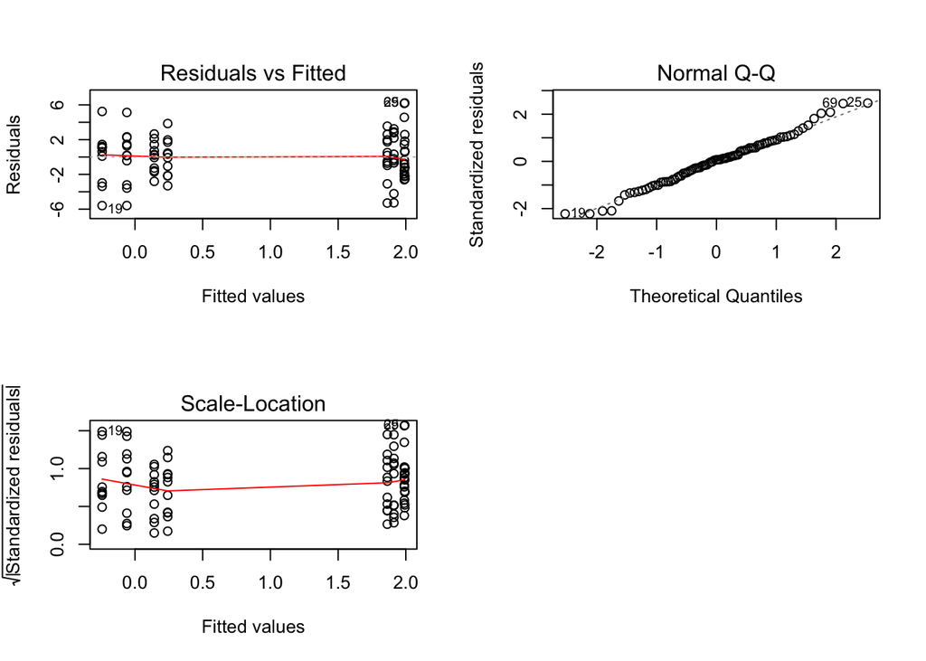

```
##
##  Shapiro-Wilk normality test
##
## data:  resid(m1)
## W = 0.98941, p-value = 0.7017
```

Based on both diagnotistic plots and Shapiro test result (p>.05), residuals are normally distributed.

4. **Model Update**  
   4.1 Firstly, remove 3-way interaction  
   4.2 Then, remove 2-way interaction  
   4.3 Check if the three removed effects together are still not significant  
   4.4 Obtain a final model with significant effect only

```
##                     Df Sum Sq Mean Sq F value   Pr(>F)
## gender               1    0.1    0.07   0.011 0.918467
## face_ori             1   81.0   80.99  11.761 0.000954 ***
## hemisphere           1    1.1    1.09   0.159 0.691176
## gender:face_ori      1    0.2    0.15   0.022 0.881781
## gender:hemisphere    1    0.0    0.00   0.000 0.986354
## face_ori:hemisphere  1    0.3    0.32   0.046 0.830488
## Residuals           81  557.8    6.89
## ---
## Signif. codes:  0 '***' 0.001 '**' 0.01 '*' 0.05 '.' 0.1 ' ' 1
```

```
##             Df Sum Sq Mean Sq F value  Pr(>F)
## gender       1    0.1    0.07   0.011 0.91700
## face_ori     1   81.0   80.99  12.187 0.00077 ***
## hemisphere   1    1.1    1.09   0.165 0.68590
## Residuals   84  558.3    6.65
## ---
## Signif. codes:  0 '***' 0.001 '**' 0.01 '*' 0.05 '.' 0.1 ' ' 1
```

```
## Analysis of Variance Table
##
## Model 1: amplitude ~ gender + face_ori + hemisphere + gender:face_ori +
##     gender:hemisphere + face_ori:hemisphere
## Model 2: amplitude ~ gender + face_ori + hemisphere
##   Res.Df    RSS Df Sum of Sq      F Pr(>F)
## 1     81 557.79
## 2     84 558.27 -3  -0.47292 0.0229 0.9953
```

```
##             Df Sum Sq Mean Sq F value   Pr(>F)
## face_ori     1   81.0   80.99   12.45 0.000673 ***
## Residuals   86  559.4    6.51
## ---
## Signif. codes:  0 '***' 0.001 '**' 0.01 '*' 0.05 '.' 0.1 ' ' 1
```

Table 4: ANOVA on N170 Amplitude with Effect Size

| term | df | sumsq | meansq | statistic | p.value | etasq | partial.etasq | omegasq | cohens.f | power |
| --- | --- | --- | --- | --- | --- | --- | --- | --- | --- | --- |
| gender | 1 | 0.07 | 0.07 | 0.01 | 0.92 | 0.00 | 0.00 | -0.01 | 0.01 | 0.05 |
| face_ori | 1 | 80.99 | 80.99 | 11.62 | 0.00 | 0.13 | 0.13 | 0.11 | 0.38 | 0.93 |
| hemisphere | 1 | 1.09 | 1.09 | 0.16 | 0.69 | 0.00 | 0.00 | -0.01 | 0.04 | 0.07 |
| gender:face_ori | 1 | 0.15 | 0.15 | 0.02 | 0.88 | 0.00 | 0.00 | -0.01 | 0.02 | 0.05 |
| gender:hemisphere | 1 | 0.00 | 0.00 | 0.00 | 0.99 | 0.00 | 0.00 | -0.01 | 0.00 | 0.05 |
| face_ori:hemisphere | 1 | 0.32 | 0.32 | 0.05 | 0.83 | 0.00 | 0.00 | -0.01 | 0.02 | 0.06 |
| gender:face_ori:hemisphere | 1 | 0.02 | 0.02 | 0.00 | 0.96 | 0.00 | 0.00 | -0.01 | 0.01 | 0.05 |
| Residuals | 80 | 557.77 | 6.97 | NA | NA | NA | NA | NA | NA | NA |

In the end, we obtain the final model with `face orientation` only, and it has a median effect size (eta-sqared = 0.13). Meaning that 13% of the total variability in the `amplitude` that is accounted for by the variation in the `face orientation`. From above effect size results, the other variables or interactions have small or very low effect size.

5. **Visualise the results**

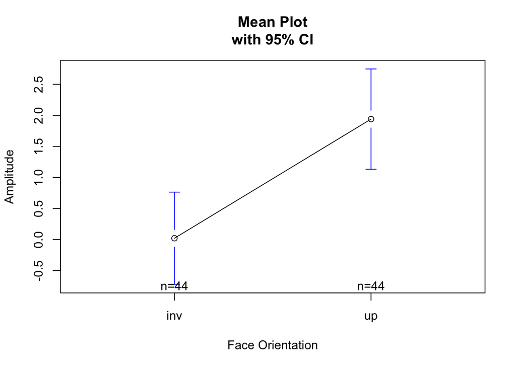

As in the mean plot, upright face elicited larger N170 amplitude than inverted face.

### ANOVA on Latency

1. **Two-way interactions plots**

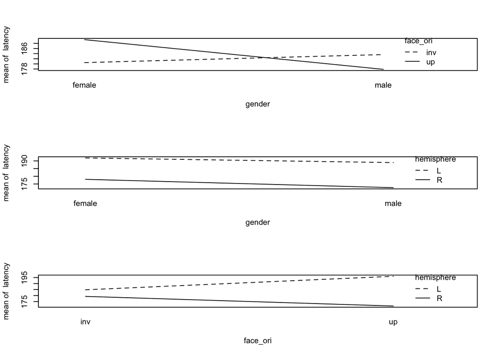

There may be two interactions between `face orientaion` vs. `gender`, and `face orientaion` vs. `hemisphere`.

2. **Fit a Model**  
   Build a full model to see whether the differences between means plotted are significant or not.

```
##
##  Shapiro-Wilk normality test
##
## data:  N170_total$latency
## W = 0.53936, p-value = 3.604e-15
```

Table 5: ANOVA on N170 Latency

|  | Df | Sum Sq | Mean Sq | F value | Pr(>F) |
| --- | --- | --- | --- | --- | --- |
| gender | 1 | 0.00 | 0.00 | 0.14 | 0.71 |
| face_ori | 1 | 0.00 | 0.00 | 0.06 | 0.80 |
| hemisphere | 1 | 0.08 | 0.08 | 2.49 | 0.12 |
| gender:face_ori | 1 | 0.01 | 0.01 | 0.44 | 0.51 |
| gender:hemisphere | 1 | 0.00 | 0.00 | 0.08 | 0.77 |
| face_ori:hemisphere | 1 | 0.03 | 0.03 | 1.00 | 0.32 |
| gender:face_ori:hemisphere | 1 | 0.01 | 0.01 | 0.34 | 0.56 |
| Residuals | 80 | 2.48 | 0.03 | NA | NA |

Table 6: ANOVA on N170 Latency with Effect Size

| term | df | sumsq | meansq | statistic | p.value | etasq | partial.etasq | omegasq | cohens.f | power |
| --- | --- | --- | --- | --- | --- | --- | --- | --- | --- | --- |
| gender | 1 | 0.00 | 0.00 | 0.14 | 0.70 | 0.00 | 0.00 | -0.01 | 0.04 | 0.07 |
| face_ori | 1 | 0.00 | 0.00 | 0.06 | 0.80 | 0.00 | 0.00 | -0.01 | 0.03 | 0.06 |
| hemisphere | 1 | 0.08 | 0.08 | 2.49 | 0.12 | 0.03 | 0.03 | 0.02 | 0.18 | 0.35 |
| gender:face_ori | 1 | 0.01 | 0.01 | 0.44 | 0.51 | 0.00 | 0.01 | -0.01 | 0.08 | 0.10 |
| gender:hemisphere | 1 | 0.00 | 0.00 | 0.08 | 0.77 | 0.00 | 0.00 | -0.01 | 0.03 | 0.06 |
| face_ori:hemisphere | 1 | 0.03 | 0.03 | 1.00 | 0.32 | 0.01 | 0.01 | 0.00 | 0.11 | 0.17 |
| gender:face_ori:hemisphere | 1 | 0.01 | 0.01 | 0.34 | 0.56 | 0.00 | 0.00 | -0.01 | 0.06 | 0.09 |
| Residuals | 80 | 2.48 | 0.03 | NA | NA | NA | NA | NA | NA | NA |